# Movielense Data: Movie Recommender Systems

CS598, Fall 2020

## Introduction And Goal

This project is to build 2 movie recommender systems based on Movielense 1M Datasets.  
And for each movie recommender systems, there will be two schemes/methods.  
- System 1 recommends 10 popular movies in each genre,and the recommended movies in each genre will be invariant in spite of different users. - System 2 recommends 10 movies based on the ratings the user provided on some movies. It is based on the ratings among similar users or items.

There are two files related in this project: movies and ratings datasets.

- `movies.dat` [[Github_link](https://liangfgithub.github.io/MovieData/movies.dat?raw=true)]
- `ratings.dat` [[Github_link](https://liangfgithub.github.io/MovieData/ratings.dat?raw=true)]

**ratings data**

|  | UserID | MovieID | Rating | Timestamp |
| --- | --- | --- | --- | --- |
| 1 | 1 | 1193 | 5 | 978300760 |
| 2 | 1 | 661 | 3 | 978302109 |
| 3 | 1 | 914 | 3 | 978301968 |
| 4 | 1 | 3408 | 4 | 978300275 |
| 5 | 1 | 2355 | 5 | 978824291 |
| 6 | 1 | 1197 | 3 | 978302268 |

**movies data** In movies.dat, some movie names contain single colon (:), so the method above does not work.

|  | MovieID | Title | Genres | Year |
| --- | --- | --- | --- | --- |
| 1 | 1 | Toy Story (1995) | Animation\|Children's\|Comedy | 1995 |
| 2 | 2 | Jumanji (1995) | Adventure\|Children's\|Fantasy | 1995 |
| 3 | 3 | Grumpier Old Men (1995) | Comedy\|Romance | 1995 |
| 4 | 4 | Waiting to Exhale (1995) | Comedy\|Drama | 1995 |
| 5 | 5 | Father of the Bride Part II (1995) | Comedy | 1995 |
| 6 | 6 | Heat (1995) | Action\|Crime\|Thriller | 1995 |

## Exploratory Date Analysis

This EDA part is provide by professor Feng Liang

### Unique Movies?

MovieID ranges from 1 to 3952, but not all of them are included in `movies`. Further, 177 movies are in `movies` but not rated in `ratings`.

### Dist of Ratings

Most of the ratings are in the 3-5 range.

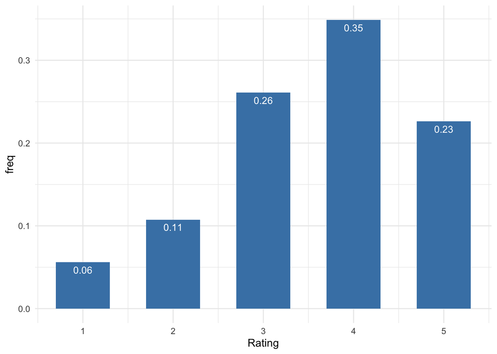

### Ratings per Movie

There are 31 movies that have received more than 2000 ratings. The most popular movie is “American Beauty (1999)”, followed by the “Star Wars” series. Throughout, **popular** means receiving many ratings; a popular movie may not be a **highly-rated** movie.

```
##    Min. 1st Qu.  Median    Mean 3rd Qu.    Max.
##     1.0    33.0   123.5   269.9   350.0  3428.0
```

```
## # A tibble: 31 x 2
##    Title                                                 ratings_per_movie
##    <chr>                                                             <int>
##  1 Alien (1979)                                                       2024
##  2 Toy Story (1995)                                                   2077
##  3 Terminator, The (1984)                                             2098
##  4 Pulp Fiction (1994)                                                2171
##  5 Ghostbusters (1984)                                                2181
##  6 Forrest Gump (1994)                                                2194
##  7 Godfather, The (1972)                                              2223
##  8 Shawshank Redemption, The (1994)                                   2227
##  9 Being John Malkovich (1999)                                        2241
## 10 Star Wars: Episode I - The Phantom Menace (1999)                   2250
## 11 E.T. the Extra-Terrestrial (1982)                                  2269
## 12 Groundhog Day (1993)                                               2278
```

[output cut: 19 more lines]

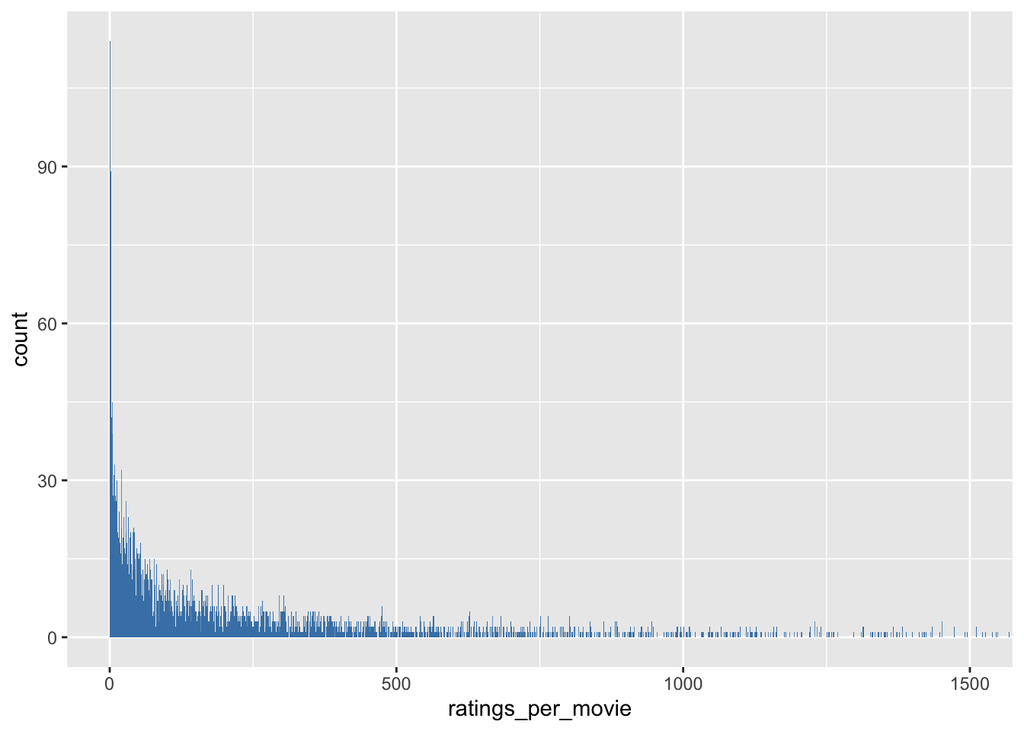

The top ten highly-rated (based on their average ratings) among all movies that have received at least 1000 ratings.

|  | Image | Title | ave_ratings |
| --- | --- | --- | --- |
| 1 |  | Sixth Sense, The (1999) | 4.406 |
| 2 |  | Casablanca (1942) | 4.413 |
| 3 |  | Dr. Strangelove or: How I Learned to Stop Worrying and Love the Bomb (1963) | 4.45 |
| 4 |  | Star Wars: Episode IV - A New Hope (1977) | 4.454 |
| 5 |  | Rear Window (1954) | 4.476 |
| 6 |  | Raiders of the Lost Ark (1981) | 4.478 |
| 7 |  | Schindler's List (1993) | 4.51 |
| 8 |  | Usual Suspects, The (1995) | 4.517 |
| 9 |  | Godfather, The (1972) | 4.525 |
| 10 |  | Shawshank Redemption, The (1994) | 4.555 |